# An introduction to the qtlr package

John Kirkpatrick

Last run on 2019-07-01 by kirkpatj on rkaub00459.kau.roche.com

# Introduction

ICH E6(R2) (Harmonisation of Technical Requirements for Pharmaceuticals for Human Use (ICH) 2016) imposes on sponsors of clinical trials an obligation to use risk based monitoring (RBM) as part of their processes to ensure the quality and integrity of clinical trials data:

> The sponsor should implement a system to manage quality throughout all stages of the trial process. … The quality management system should use a risk-based approach.

Further this RBM system should use quality tolerance limits (QTLs) to provide objective measures of a tool in assessing the overall quality of individual clinical trials and of overall development programmes:

> Predefined quality tolerance limits should be established, taking into consideration the medical and statistical characteristics of the variables as well as the statistical design of the trial, to identify systematic issues that can impact subject safety or reliability of trial results. Detection of deviations from the predefined quality tolerance limits should trigger an evaluation to determine if action is needed.

This vignette describes one possible implementation of QTLs. The choice of metrics on which the QTLs are based is out-of-scope for this vignette.

# Installing and using the qtlr package

Use of the package is straightforward. Before using it for the first time, it must be installed:

`install.packages("qtlr")`

Then, to use `qtlr` in an R script, it must be loaded and attached:

`library(qtlr)`

Internally, `qtlr` uses JAGS (Plummer 2017) to fit models and the `runjags` package (Denwood 2016) to provide the interface between R and JAGS. Therefore, you must ensure that JAGS is installed on your system before using `qtlr`. Installing `qtlr` will also install `runjags` and other required packages if necessary.

# First example

As an introductory example, and to provide initial validation of the implementation, we reproduce the meta-analysis of clinical trial results presented in Example 2.7 of Berry et al (SM Berry 2010). Rather than being response rates reported in a number of clinical trials, we interpret their data as providing the number of participants at each site in a single multicentre study, together with the number of participants who met some arbitrary metric (for example, reporting at least one cardiac adverse event of CTCAE grade 2 or higher, having at least one out-of-window study visit or being the subject of at least one data clarification caused by apparently missing CRF items).

## The raw data

The raw data in Berry et al’s example is provided by the utility function `createBerryData`:

```r
b <- createBerryData()
b %>% kable(digits=c(0,0,0,3))
```

| Study | Subjects | Events | ObservedResponse |
| --- | --- | --- | --- |
| 1 | 20 | 20 | 1.000 |
| 2 | 10 | 4 | 0.400 |
| 3 | 16 | 11 | 0.688 |
| 4 | 19 | 10 | 0.526 |
| 5 | 14 | 5 | 0.357 |
| 6 | 46 | 36 | 0.783 |
| 7 | 10 | 9 | 0.900 |
| 8 | 9 | 7 | 0.778 |
| 9 | 6 | 4 | 0.667 |

## Estimating the QTLs

```r
m <- fitBinomialModel(b$Subjects, b$Events)
```

```
#>
#> Auto-run JAGS
#>
#> Running a pilot chain...
#> Compiling rjags model...
#> Calling the simulation using the rjags method...
#> Adapting the model for 1000 iterations...
#> Burning in the model for 4000 iterations...
#> Running the model for 10000 iterations...
#> Simulation complete
#> Finished running the simulation
#>
#> Calculating the Gelman-Rubin statistic for 12 variables....
#> The Gelman-Rubin statistic is below 1.05 for all parameters
#>
#> Calculating the necessary sample length based on the Raftery and
#> Lewis's diagnostic...
#> Indicated sample length achieved
#> Auto-run JAGS complete
```

```r
m
```

```
#> # A tibble: 240,000 x 5
#>    Chain Sample Parameter Index Value
#>    <int>  <dbl> <chr>     <int> <dbl>
#>  1     1   5001 p             1 0.896
#>  2     1   5001 p             2 0.689
#>  3     1   5001 p             3 0.641
#>  4     1   5001 p             4 0.567
#>  5     1   5001 p             5 0.505
#>  6     1   5001 p             6 0.824
#>  7     1   5001 p             7 0.950
#>  8     1   5001 p             8 0.753
#>  9     1   5001 p             9 0.809
#> 10     1   5001 p            10 0.359
#> # … with 239,990 more rows
```

`Parameter` indicates the parameter being sampled. In this case `a` and `b` are the hyperparameters used to define the prior distributions of the `p`s and `p` is the sampled probability that a participant at the centre given by the value of `Index` reports an event. Note that `Index` refers to the row of the input vectors `n` and `r`, not to any id variable that may exist in the input dataset. The input vectors `n` and `r` are augmented with a pseudo observation which allows prediction of the probability that a participant at an arbitrary centre will report an event. The MCMC samples can easily be summarised to obtain the fitted event probabilities.

```r
results <-  m %>%
              filter(Parameter == "p") %>%
              group_by(Parameter, Index) %>%
              summarise(Fitted=mean(Value)) %>%
              ungroup()
results %>%
   kable(digits=c(NA, 0, 2))
```

| Parameter | Index | Fitted |
| --- | --- | --- |
| p | 1 | 0.90 |
| p | 2 | 0.53 |
| p | 3 | 0.68 |
| p | 4 | 0.57 |
| p | 5 | 0.48 |
| p | 6 | 0.77 |
| p | 7 | 0.80 |
| p | 8 | 0.73 |
| p | 9 | 0.68 |
| p | 10 | 0.68 |

The results of this analysis can be combined with the original input data to reproduce the information in table 2.2 on page 63 of Berry et al.

```r
berry <- results %>%
           mutate(Study=1:10) %>%
           left_join(b, by="Study") %>%
           select(Index, Subjects, Events, ObservedResponse, Fitted, -Parameter, -Study)
berry %>% kable(col.names=c("Centre", "Subjects", "Events", "Observed", "Fitted"),
                digits=c(0, 0, 0, 2, 2))
```

| Centre | Subjects | Events | Observed | Fitted |
| --- | --- | --- | --- | --- |
| 1 | 20 | 20 | 1.00 | 0.90 |
| 2 | 10 | 4 | 0.40 | 0.53 |
| 3 | 16 | 11 | 0.69 | 0.68 |
| 4 | 19 | 10 | 0.53 | 0.57 |
| 5 | 14 | 5 | 0.36 | 0.48 |
| 6 | 46 | 36 | 0.78 | 0.77 |
| 7 | 10 | 9 | 0.90 | 0.80 |
| 8 | 9 | 7 | 0.78 | 0.73 |
| 9 | 6 | 4 | 0.67 | 0.68 |
| 10 | NA | NA | NA | 0.68 |

## Presenting the results to end-users

The `qtlFromQuantile` function allows the simple conversion of QTLs based on the quantiles of the fitted model to those based on quantiles of the underlying metric. For example, the following snippet determines the event rates correspnding to the 10th, 20th, 80th and 90th quantiles of the fitted model.

```r
postEx1 <- m %>% filter(Index == 10)
limits <- qtlFromQuantile(postEx1, c(0.1, 0.2, 0.8, 0.9))
limits %>%  kable(digits=3)
```

| Prob | Quantile |
| --- | --- |
| 0.1 | 0.447 |
| 0.2 | 0.540 |
| 0.8 | 0.835 |
| 0.9 | 0.892 |

Taking the 10th and 90th quantiles to define (lower and upper) investigation limits and the 20th and 80th quantiles to define (lower and upper) warning limits, we can categorise each site in the study…

```r
berry <- berry %>%
           mutate(Band=cut(Fitted,
                           breaks=c(-Inf, limits$Quantile, Inf),
                           labels=c("Investigation low", "Warn low", "OK", "Warn high", "Investigation high")))
berry %>%
  kable(col.names=c("Centre", "Subjects", "Events", "Observed", "Fitted", "QTL band"),
        digits=c(0, 0, 0, 2, 2))
```

| Centre | Subjects | Events | Observed | Fitted | QTL band |
| --- | --- | --- | --- | --- | --- |
| 1 | 20 | 20 | 1.00 | 0.90 | Investigation high |
| 2 | 10 | 4 | 0.40 | 0.53 | Warn low |
| 3 | 16 | 11 | 0.69 | 0.68 | OK |
| 4 | 19 | 10 | 0.53 | 0.57 | OK |
| 5 | 14 | 5 | 0.36 | 0.48 | Warn low |
| 6 | 46 | 36 | 0.78 | 0.77 | OK |
| 7 | 10 | 9 | 0.90 | 0.80 | OK |
| 8 | 9 | 7 | 0.78 | 0.73 | OK |
| 9 | 6 | 4 | 0.67 | 0.68 | OK |
| 10 | NA | NA | NA | 0.68 | OK |

… or present only those sites which fall outside a QTL:

```r
berry %>%
  filter(Band != "OK") %>%
  kable(col.names=c("Centre", "Subjects", "Events", "Observed", "Fitted", "QTL band"),
        digits=c(0, 0, 0, 2, 2))
```

| Centre | Subjects | Events | Observed | Fitted | QTL band |
| --- | --- | --- | --- | --- | --- |
| 1 | 20 | 20 | 1.00 | 0.90 | Investigation high |
| 2 | 10 | 4 | 0.40 | 0.53 | Warn low |
| 5 | 14 | 5 | 0.36 | 0.48 | Warn low |

The action may involve changes at the site in question or at other sites. For example, suppose the metric being considered in the incidence of injection site reactions (ISRs) and that one particular site falls into the “investigation low” category. In other words, taking account of the inherent variability in ISR rates between sites, the rate observed at this site is sufficiently low to suggest that it is different to that observed at other sites. Consider two scenarios. In the first, suppose the site staff consider that, in this indication and using this mode of therapy, ISRs are simply “par for the course” and therefore not worth reporting. Here, the appropriate remedial action might be to retrain the site staff to make them more aware of the necessity of comprehensive and unbiased reporting of all safety data related to the study treatments.

Alternatively, suppose that the site’s chief investigator acknowledges the importance of ISRs because of their potential impact, not only on safety, but also on the comfort and convenience of the participants in the study. The CI reports that it is standard practice at his site to prophylactically apply “magic cream” to the site of any planned infusion about 15 minutes before the the start of treatment. The site has found this to be beneficial in the past and, since it is not explicitly contra-indicated by the study protocol, the site staff saw no reason to deviate from their usual standard of care. In this case, the appropriate action might be to suggest prophylaxis with “magic cream” at all other sites involved in the study.

### Graphical presentations

Graphical prsentations have obvious advantages compared to tabulations. We adapt figure 2.9 on page 62 of Berry et al (SM Berry 2010). The `createQtlPlot` function can be called to plot the posterior distribution of the probability of event overlaid with the observed site-specific rates and QTL bands. The default plot is deliberately crude, but is easily customised, as demonstrated below.

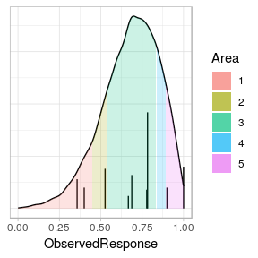

```r
createQtlPlot(mcmcData=postEx1,
              groupData=berry %>% filter(Index < 10),
              groupResponse=ObservedResponse,
              groupSize=Subjects)
```

The vertical bars in the plot show the observed group-specific event rates and the size of each group: the rate is indicated by their positions on the x-axis and their heights are proportional to the number of observations in the group. The curve shows the posterior distribution of the probability of an event for participants in an arbitrary new group. The shading shows the locations of the QTL bands, which by default are defined by the 10th, 20th, 80th and 90th centiles of the posterior.

The value returned by `createQtlPlot` is a `ggplot2` object so it is easy to customise and chain. For example, the next code snippet changes the label and shading of the QTL bands.

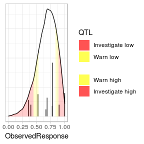

```r
qtlColours <- c("red", "yellow", "white", "yellow", "red")
qtlLabels <-c("Investigate low", "Warn low", "", "Warn high", "Investigate high")
qtlScale <- scale_fill_manual(name="QTL", labels=qtlLabels, values=qtlColours)
createQtlPlot(groupData=b,
              groupResponse=ObservedResponse,
              groupSize=Subjects,
              mcmcData=postEx1) +
  qtlScale
```

Other aspects of the plot’s appearance can be customised using standard `theme` elements or the `labs` function:

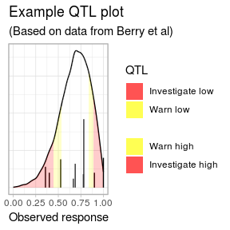

```r
createQtlPlot(groupData=b,
              groupResponse=ObservedResponse,
              groupSize=Subjects,
              mcmcData=postEx1) +
  qtlScale +
  labs(x="Observed response",
       title="Example QTL plot",
       subtitle="(Based on data from Berry et al)")
```

The number QTL bands and their boundaries can be modified or suppressed by using the `qtls` argument.

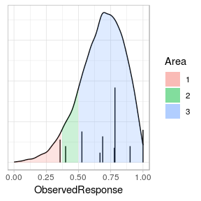

```r
createQtlPlot(groupData=b,
              groupResponse=ObservedResponse,
              groupSize=Subjects,
              mcmcData=postEx1,
              qtls=c(0.05, 0.15))
```

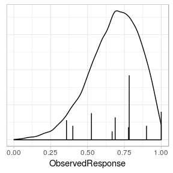

```r
createQtlPlot(groupData=b,
              groupResponse=ObservedResponse,
              groupSize=Subjects,
              mcmcData=postEx1,
              qtls=NULL)
```

The groups can be categorised by using the `groupType` argument

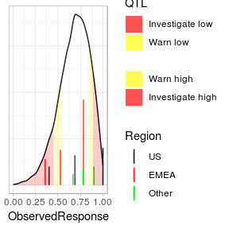

```r
b1 <- b %>% mutate(Region=as.factor(c(1, 1, 1, 2, 2, 2, 3, 3, 3)))
regionScale <- scale_colour_manual(name="Region",
                                   values=1:3,
                                   labels=c("US", "EMEA", "Other"))
createQtlPlot(groupData=b1,
              groupResponse=ObservedResponse,
              groupSize=Subjects,
              mcmcData=postEx1,
              groupType=Region) +
  qtlScale +
  regionScale
```

By default, the posterior density is scaled so that its height at the mode is twice that of the tallest group size bar. To change this behaviour, use the `postScaleFactor` argument. The posterior density is based on the *scaled* kernel density estimate produced by `ggplot2::geom_density`, which has a height of `1` at the mode. To set the modal height of the density to an absolute value, use `postScaleFactor=<constant>`. To set the modal height of the density to a multiple of the largest group size, use `postScaleFactor=<constant>*max(groupData$groupSize)`. For example, to rescale the previous plot:

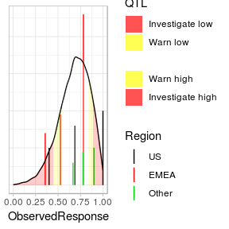

```r
createQtlPlot(groupData=b1,
              groupResponse=ObservedResponse,
              groupSize=Subjects,
              mcmcData=postEx1,
              groupType=Region,
              postScaleFactor=0.75*max(b1$Subjects)) +
  qtlScale +
  regionScale
```

# Other data types

The discussion so far has related only to binomial data. `qtlr` also supports

- Rate or event count data
- Time-to-event data
- Continuous data

One generic function facilitates the presentation of QTLs for the different date types: `fitModel(type)` is a wrapper function that calls the appropriate `fitXXXXModel` function and passes the necessary parameters to the type specific funtion using `...`. `createQtlPlot` and `createQtlBubblePlot` are inherently generic. Naturally, the type-specific model-fitting functions can be called directly.

## Binary data

The following snippet reproduces the analysis of the Berry data, but uses subject- rather than study-level input data.

```r
berrySubjects <- createBerryData(TRUE)
mBinary <- fitBinaryModel(berrySubjects$Event, berrySubjects$Study)
```

```
#>
#> Auto-run JAGS
#>
#> Running a pilot chain...
#> Compiling rjags model...
#> Calling the simulation using the rjags method...
#> Adapting the model for 1000 iterations...
#> Burning in the model for 4000 iterations...
#> Running the model for 10000 iterations...
#> Simulation complete
#> Finished running the simulation
#>
#> Calculating the Gelman-Rubin statistic for 12 variables....
#> The Gelman-Rubin statistic is below 1.05 for all parameters
#>
#> Calculating the necessary sample length based on the Raftery and
#> Lewis's diagnostic...
#> Indicated sample length achieved
#> Auto-run JAGS complete
```

```r
results <-  mBinary %>%
              filter(Parameter == "p") %>%
              group_by(Parameter, Index) %>%
              summarise(Fitted=mean(Value)) %>%
              ungroup()
results %>%
   kable(digits=c(NA, 0, 2))
```

| Parameter | Index | Fitted |
| --- | --- | --- |
| p | 1 | 0.91 |
| p | 2 | 0.53 |
| p | 3 | 0.69 |
| p | 4 | 0.57 |
| p | 5 | 0.48 |
| p | 6 | 0.77 |
| p | 7 | 0.80 |
| p | 8 | 0.73 |
| p | 9 | 0.67 |
| p | 10 | 0.68 |

## Poisson data: rates or event counts

As an illustration of the QTL methodology applied to event counts, we analyse the number of soldiers in 14 Prussian cavalry Corps kicked to death by horses each year from 1875 to 1894 (Bortkiewicz 1898). This dataset is included in the `qltr` package in the `cavalryDeaths` tibble. We calculate the total number of deaths during the period for each Corps together with the number of years over which the data were collected before calling `fitPoissonModel`.

When analysing event counts, `qtlr` fits a model to the total number of events observed in each group but predicts the expected number of events *per unit time*. Therefore, it is appropriate to use the `DeathsPerYear` column when creating the QTL plot.

```r
cavalrySummary <- cavalryDeaths %>%
                    group_by(Corps) %>%
                    summarise(Deaths=sum(Deaths),
                              Duration=n()) %>%
                    mutate(DeathsPerYear=Deaths/Duration) %>%
                    ungroup()
cavalrySummary %>% kable()
```

| Corps | Deaths | Duration | DeathsPerYear |
| --- | --- | --- | --- |
| Guards | 16 | 20 | 0.80 |
| Corps 1 | 16 | 20 | 0.80 |
| Corps 2 | 12 | 20 | 0.60 |
| Corps 3 | 12 | 20 | 0.60 |
| Corps 4 | 8 | 20 | 0.40 |
| Corps 5 | 11 | 20 | 0.55 |
| Corps 6 | 17 | 20 | 0.85 |
| Corps 7 | 12 | 20 | 0.60 |
| Corps 8 | 7 | 20 | 0.35 |
| Corps 9 | 13 | 20 | 0.65 |
| Corps 10 | 15 | 20 | 0.75 |
| Corps 11 | 25 | 20 | 1.25 |
| Corps 14 | 24 | 20 | 1.20 |
| Corps 15 | 8 | 20 | 0.40 |

```r
postCavalry <- fitPoissonModel(cavalrySummary$Deaths, cavalrySummary$Duration)
```

```
#>
#> Auto-run JAGS
#>
#> Running a pilot chain...
#> Compiling rjags model...
#> Calling the simulation using the rjags method...
#> Adapting the model for 1000 iterations...
#> Burning in the model for 4000 iterations...
#> Running the model for 10000 iterations...
#> Simulation complete
#> Finished running the simulation
#>
#> Calculating the Gelman-Rubin statistic for 17 variables....
#> The Gelman-Rubin statistic is below 1.05 for all parameters
#>
#> Calculating the necessary sample length based on the Raftery and
#> Lewis's diagnostic...
#> The model will need to be run for a further 12140 updates.  This
#> will take approximately 1.7 seconds.
#>
#> Calling the simulation using the rjags method...
#> Note: the model did not require adaptation
#> Running the model for 12140 iterations...
#> Simulation complete
#> Finished running the simulation
#> Indicated sample length achieved
#> Auto-run JAGS complete
```

```r
results <-  postCavalry %>%
              filter(Parameter == "mu") %>%
              group_by(Parameter, Index) %>%
              summarise(Fitted=mean(Value)) %>%
              ungroup()
limits <- qtlFromQuantile(postCavalry %>% filter(Index == 15), c(0.1, 0.2, 0.8, 0.9))

cavalrySummary <- cavalrySummary %>%
                    add_column(Index=1:14) %>%
                    left_join(results, by="Index") %>%
                    select(Corps, Deaths, Duration, DeathsPerYear, Fitted) %>%
                    mutate(Band=cut(Fitted/Duration,
                                    breaks=c(-Inf, limits$Quantile, Inf),
                                    labels=c("Investigation low", "Warn low",
                                             "OK", "Warn high",
                                             "Investigation high")))

cavalrySummary %>% kable(col.names=c("Corps", "Deaths", "Duration", "Deaths per year", "Fitted", "Band"),
                         digits=c(NA, 0, 0, 2, 2, NA))
```

| Corps | Deaths | Duration | Deaths per year | Fitted | Band |
| --- | --- | --- | --- | --- | --- |
| Guards | 16 | 20 | 0.80 | 15.67 | OK |
| Corps 1 | 16 | 20 | 0.80 | 15.65 | OK |
| Corps 2 | 12 | 20 | 0.60 | 12.44 | OK |
| Corps 3 | 12 | 20 | 0.60 | 12.44 | OK |
| Corps 4 | 8 | 20 | 0.40 | 9.27 | OK |
| Corps 5 | 11 | 20 | 0.55 | 11.64 | OK |
| Corps 6 | 17 | 20 | 0.85 | 16.47 | OK |
| Corps 7 | 12 | 20 | 0.60 | 12.46 | OK |
| Corps 8 | 7 | 20 | 0.35 | 8.46 | OK |
| Corps 9 | 13 | 20 | 0.65 | 13.27 | OK |
| Corps 10 | 15 | 20 | 0.75 | 14.88 | OK |
| Corps 11 | 25 | 20 | 1.25 | 22.85 | Warn high |
| Corps 14 | 24 | 20 | 1.20 | 22.08 | Warn high |
| Corps 15 | 8 | 20 | 0.40 | 9.25 | OK |

```r
limits %>%  kable(digits=3, caption="QTL limits for the cavalry data")
```

QTL limits for the cavalry data

| Prob | Quantile |
| --- | --- |
| 0.1 | 0.271 |
| 0.2 | 0.379 |
| 0.8 | 1.020 |
| 0.9 | 1.282 |

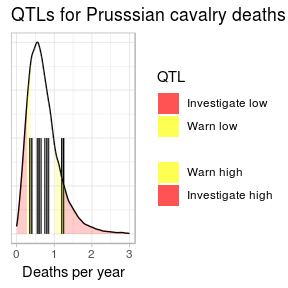

```r
createQtlPlot(mcmcData=postCavalry %>% filter(Index == 15, Value < 3),
              groupData=cavalrySummary,
              groupSize=Duration,
              groupResponse=DeathsPerYear) +
  qtlScale +
  labs(x="Deaths per year",
       title="QTLs for Prusssian cavalry deaths")
```

## Time-to-event data

We use the VA Lung dataset (Kalbfleisch and Prentice 1980) to illustrate the methodology, using `CellType` as the grouping variable. Note that in this example the plot excludes approximately 10% of the MCMC samples to remove some outliers and improve the appearance of the graphic.

```r
vaLungSummary <- vaLung %>%
                   group_by(CellType) %>%
                   summarise(N=n(),
                             Deaths=sum(Status),
                             Censored=N-sum(Status),
                             SurvivalTime=sum(SurvivalTime),
                             MeanSurvival=SurvivalTime/Deaths)

results <- fitTteModel(time=vaLung$SurvivalTime,
                       status=vaLung$Status,
                       g=vaLung$CellType)
```

```
#>
#> Auto-run JAGS
#>
#> Running a pilot chain...
#> Compiling rjags model...
#> Calling the simulation using the rjags method...
#> Adapting the model for 1000 iterations...
#> Burning in the model for 4000 iterations...
#> Running the model for 10000 iterations...
#> Simulation complete
#> Finished running the simulation
#>
#> Calculating the Gelman-Rubin statistic for 6 variables....
#> The Gelman-Rubin statistic was above 1.05 for 1 parameter after
#> 15000 iterations taking 0.3 seconds (multi-variate psrf = 1.001).
#> This may indicate poor convergence.
#> Extending the simulation to attempt to improve convergence...
#> Calling the simulation using the rjags method...
#> Note: the model did not require adaptation
#> Running the model for 10000 iterations...
#> Simulation complete
#> Finished running the simulation
#> Calculating the Gelman-Rubin statistic for 6 variables....
#> The Gelman-Rubin statistic is now below 1.05 for all parameters
#>
#> Calculating the necessary sample length based on the Raftery and
#> Lewis's diagnostic...
#> The model will need to be run for a further 293880 updates.  This
#> will take approximately 6.2 seconds.
#>
#> Calling the simulation using the rjags method...
#> Note: the model did not require adaptation
#> Running the model for 293880 iterations...
#> Simulation complete
#> Finished running the simulation
#> Indicated sample length achieved
#> Auto-run JAGS complete
```

```r
quantile(results$Value, probs=c(0.90, 0.95, 0.975, 0.99))
```

```
#>          90%          95%        97.5%          99%
#> 3.378284e+02 2.691500e+05 1.544149e+11 2.211659e+23
```

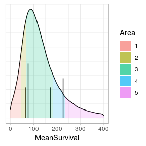

```r
createQtlPlot(mcmcData=results %>% filter(Index == 5, Value < 400),
              groupData=vaLungSummary,
              groupResponse=MeanSurvival)
```

## Continuous data

The operation of the model on Normal data is illustrated using an artificial dataset.

```r
#Generate data
nCentres <- 6
minSize <- 8
maxSize <- 25
centreSizes <- ceiling(runif(nCentres, min=minSize, max=maxSize))

group <- rep(1:nCentres, times=centreSizes)
centreMeans <- rnorm(nCentres, mean=5, sd=1.5)

data <- tibble(SubjectID=1:length(group),
               Group=group,
               Mean=rep(centreMeans, times=centreSizes),
               Y=rnorm(length(group), Mean, 3))

groupSummary <- data %>%
                  group_by(Group) %>%
                  summarise(N=n(),
                            TrueMean=mean(Mean),
                            ObservedMean=mean(Y))

#Analyse
results <- fitNormalModel(x=data$Y, g=data$Group)
```

```
#>
#> Auto-run JAGS
#>
#> Running a pilot chain...
#> Compiling rjags model...
#> Calling the simulation using the rjags method...
#> Adapting the model for 1000 iterations...
#> Burning in the model for 4000 iterations...
#> Running the model for 10000 iterations...
#> Simulation complete
#> Finished running the simulation
#>
#> Calculating the Gelman-Rubin statistic for 8 variables....
#> The Gelman-Rubin statistic is below 1.05 for all parameters
#>
#> Calculating the necessary sample length based on the Raftery and
#> Lewis's diagnostic...
#> Indicated sample length achieved
#> Auto-run JAGS complete
```

```r
summary <- results %>%
             filter(Index > 0) %>%
             rename(Group=Index) %>%
             group_by(Group) %>%
             summarise(FittedMean=mean(Value)) %>%
             ungroup()

#Report
groupSummary %>%
  full_join(summary, by="Group") %>%
  kable(digits=2,
        col.names=c("Group", "Subjects", "True","Observed","Fitted"),
        caption="Group 7 is the pseudo-group representing future data") %>%
  add_header_above(c(" "=2, "Mean"=3))
```

[output not shown]

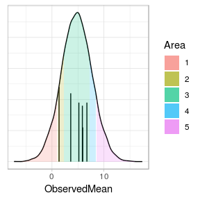

```r
createQtlPlot(mcmcData=results %>% filter(Index==7),
              groupData=groupSummary,
              groupResponse=ObservedMean,
              groupSize=N)
```

# Digging deeper

## Default model specifications

The default `qtlr` models can be obtained from the utility function `getModelString`. For example:

```r
s <- getModelString("binomial")
s %>% str_split("\\n")
```

```
#> [[1]]
#>  [1] "model"
#>  [2] "                   {"
#>  [3] "                      for (i in 1:k)"
#>  [4] "                      {"
#>  [5] "                         r[i] ~ dbin(p[i], n[i])"
#>  [6] "                         p[i] ~ dbeta(a, b)"
#>  [7] "                      }"
#>  [8] "                      a ~ dunif(0, 10)"
#>  [9] "                      b ~ dunif(0, 10)"
#> [10] "                   }"
```

## Binary data

As a convenience, binomial data can be presented at the participant level - in other words as binary data. The default model string for binary data differs only slightly from that for binary data.

```r
s <- getModelString("binary")
s %>% str_split("\\n")
```

```
#> [[1]]
#>  [1] "model"
#>  [2] "                 {"
#>  [3] "                   for (j in 1:m)"
#>  [4] "                   {"
#>  [5] "                     p[j] ~ dbeta(a, b)"
#>  [6] "                   }"
#>  [7] "                   for (i in 1:k)"
#>  [8] "                   {"
#>  [9] "                     r[i] ~ dbern(p[group[i]])"
#> [10] "                   }"
#> [11] "                   a ~ dunif(0, 10)"
#> [12] "                   b ~ dunif(0, 10)"
#> [13] "                 }"
```

`fitBinaryModel` constructs its own group index based on the value of the `g` argument, by converting this vector to a factor and then creating an appropriate index. There is no need to ensure that the user-supplied group id vector contains only integers in the range `1` to `ngroups`. The hyperpriors for binary data are identical to the hyperpriors for binomial data.

## Poisson data: rates or event counts

The `qtlr` model for rate or event count data assumes that the mean numbers of events per unit time across centres are drawn from a common distribution. This rate per unit time is then scaled by the exposure reported at each centre. The definition of exposure is arbitrary.

```r
s <- getModelString("poisson")
s %>% str_split("\\n")
```

```
#> [[1]]
#>  [1] "model "
#>  [2] "               {"
#>  [3] "                 for (i in 1:k)"
#>  [4] "                 {"
#>  [5] "                   events[i] ~ dpois(mu[i])"
#>  [6] "                   mu[i] <- lambda[i]*exposure[i]"
#>  [7] "                   lambda[i] ~ dgamma(shape, 1/scale)"
#>  [8] "                 }"
#>  [9] "                 scale ~ dgamma(1, 1)"
#> [10] "                 shape ~ dgamma(1, 1)"
#> [11] "               }"
```

The priors for the λ<sub>i</sub>, the mean rates per unit time in each group, are Gamma(α, β). The hyperparameters α and β are both assumed to have a Gamma(1, 1) prior.

## Time-to-event data

Analysis of time-to-event data is slightly different to the analysis of other data types in `qtlr`. In order to obtain *group* level estimates from *subject* level input data, `fitTteModel` first calculates group-level mean times to event as

$\frac{\Sigma t _i}{n _i}$

The log mean survival times are assumed to be Normally distributed. The prior means are drawn from a Normal distribution with mean zero and *precision* 1x10<sup>-6</sup>. The common prior *precision* of the group means is taken from an inverse Gamma distribution with shape and scale both equal to 1x10<sup>-6</sup>.

```r
s <- getModelString("tte")
s %>% str_split("\\n")
```

```
#> [[1]]
#>  [1] "model"
#>  [2] "                {"
#>  [3] "                  #Likelihood"
#>  [4] "                  for (i in 1:k)"
#>  [5] "                  {"
#>  [6] "                     logMean[i] ~ dnorm(mu[i], n[i] / tau)"
#>  [7] "                  }"
#>  [8] "                  #Prior"
#>  [9] "                  for (i in 1:k)"
#> [10] "                  {"
#> [11] "                     mu[i] ~ dnorm(mu0, tau)"
#> [12] "                  }"
#> [13] "                  mu0 ~ dnorm(0, 1e-06)"
#> [14] "                  invTau ~ dgamma(1e-06, 1e-06)"
#> [15] "                  #Transform"
#> [16] "                  tau <- 1/invTau  # Because inverse gamma isn't directly supported"
#> [17] "                }"
```

By their very nature, time-to-event analyses may require both longer chains and larger observed datasets than other data types before stable results can be obtained.

## Continuous data

```r
s <- getModelString("normal")
s %>% str_split("\\n")
```

```
#> [[1]]
#>  [1] "model"
#>  [2] "                {"
#>  [3] "                  #Likelihood"
#>  [4] "                  for (i in 1:n)"
#>  [5] "                  {"
#>  [6] "                     x[i] ~ dnorm(mu[g[i]], tau)"
#>  [7] "                  }"
#>  [8] "                  #Prior"
#>  [9] "                  for (i in 1:k)"
#> [10] "                  {"
#> [11] "                     mu[i] ~ dnorm(mu0, tau)"
#> [12] "                  }"
#> [13] "                  mu0 ~ dnorm(0, 1e-06)"
#> [14] "                  invTau ~ dgamma(1e-06, 1e-06)"
#> [15] "                  #Transform"
#> [16] "                  tau <- 1/invTau  # Because inverse gamma isn't directly supported"
#> [17] "                }"
```

## Using custom models

A custom model can be fitted by providing a non-`NULL` value for the `modelString` parameter in the call to `fitXXXXModel`. For example, the following code snippet changes the hyperpriors for `a` and `b` in the binomial QTL model to the exponential distribution with mean `1` and left-truncates them at `1`:

```r
s <- getModelString("binomial")
customModel <- s %>% stringr::str_replace_all("dunif\\(0, 10\\)", "dexp\\(1\\) T\\(1,\\)")
customModel %>% stringr::str_split("\\n")
```

```
#> [[1]]
#>  [1] "model"
#>  [2] "                   {"
#>  [3] "                      for (i in 1:k)"
#>  [4] "                      {"
#>  [5] "                         r[i] ~ dbin(p[i], n[i])"
#>  [6] "                         p[i] ~ dbeta(a, b)"
#>  [7] "                      }"
#>  [8] "                      a ~ dexp(1) T(1,)"
#>  [9] "                      b ~ dexp(1) T(1,)"
#> [10] "                   }"
```

```r
m2 <- fitBinomialModel(b$Subjects, b$Events, modelString=customModel)
```

```
#>
#> Auto-run JAGS
#>
#> Running a pilot chain...
#> Compiling rjags model...
#> Calling the simulation using the rjags method...
#> Adapting the model for 1000 iterations...
#> Burning in the model for 4000 iterations...
#> Running the model for 10000 iterations...
#> Simulation complete
#> Finished running the simulation
#>
#> Calculating the Gelman-Rubin statistic for 12 variables....
#> The Gelman-Rubin statistic is below 1.05 for all parameters
#>
#> Calculating the necessary sample length based on the Raftery and
#> Lewis's diagnostic...
#> Indicated sample length achieved
#> Auto-run JAGS complete
```

Of course, a custom model string could be built from scratch if so desired.

## Model checking

The tibble returned by default from `fitXXXXModel` is a convenient basis for the presentation results from a QTL analysis. It is less convenient when checking the technical adequacy of the model itself. In this case, the raw value returned from `run.jags()` would be more hepful so that it could, for example, be used directly with `coda` functions. This can be achieved by setting the `raw` parameter to `TRUE`:

```r
fitBinomialModel(b$Subjects, b$Events, raw=TRUE)
```

```
#>
#> Auto-run JAGS
#>
#> Running a pilot chain...
#> Compiling rjags model...
#> Calling the simulation using the rjags method...
#> Adapting the model for 1000 iterations...
#> Burning in the model for 4000 iterations...
#> Running the model for 10000 iterations...
#> Simulation complete
#> Finished running the simulation
#>
#> Calculating the Gelman-Rubin statistic for 12 variables....
#> The Gelman-Rubin statistic is below 1.05 for all parameters
#>
#> Calculating the necessary sample length based on the Raftery and
#> Lewis's diagnostic...
#> Indicated sample length achieved
#> Auto-run JAGS complete
#>
#> JAGS model summary statistics from 20000 samples (chains = 2; adapt+burnin = 5000):
#>
#>       Lower95  Median Upper95    Mean       SD Mode      MCerr MC%ofSD
#> a       2.199  6.0008  9.9914  5.9651   2.3035   --   0.059237     2.6
#> b     0.61714  2.6844  5.3146  2.8317   1.2968   --   0.033414     2.6
#> p[1]  0.78523 0.91584       1 0.90487 0.063134   -- 0.00098381     1.6
#> p[2]  0.28274 0.52879 0.75353 0.52574  0.12089   --  0.0011515       1
#> p[3]  0.49723 0.68919 0.86625 0.68355 0.095195   -- 0.00072813     0.8
#> p[4]  0.38943 0.57477  0.7616 0.57209 0.096226   -- 0.00076647     0.8
#> p[5]  0.26362 0.47666 0.68631  0.4755   0.1095   --  0.0011276       1
#> p[6]  0.65384 0.77023 0.87472  0.7667 0.057549   -- 0.00046935     0.8
#> p[7]  0.61067 0.81192 0.97178 0.80117 0.097537   --  0.0010489     1.1
#> p[8]  0.51909 0.73829 0.93386 0.73008  0.10879   -- 0.00093775     0.9
#> p[9]  0.42626 0.68366 0.90913 0.67446  0.12593   -- 0.00098955     0.8
#> p[10] 0.36354 0.69634 0.99286 0.68004  0.17212   --  0.0013227     0.8
#>
#>       SSeff      AC.10    psrf
#> a      1512    0.23803  1.0007
#> b      1506    0.22843  1.0008
#> p[1]   4118   0.071492  1.0001
#> p[2]  11021   0.005039       1
#> p[3]  17092 -0.0018748 0.99999
#> p[4]  15762  -0.012656 0.99998
#> p[5]   9431   0.015034       1
#> p[6]  15034 0.00018598  1.0002
#> p[7]   8648   0.019828  1.0005
#> p[8]  13459 -0.0026698  1.0002
#> p[9]  16194 -0.0068384  1.0003
#> p[10] 16932  0.0028157       1
#>
#> Total time taken: 4.3 seconds
```

## Modifying the MCMC analysis

By default, the MCMC analysis used to fit the QTL models uses two chains, each of length 10000 with a burn-in of 4000, an adaptation period of 1000 and no thinning. These are the `runjags` defaults. The `fitXXXXModel` functions use `...` to pass parameters to `run.jags`. This provides an easy mechanism for adapting the underlying MCMC analysis.

```r
m <- fitBinomialModel(b$Subjects, b$Events,
                      burnin=2000,
                      sample=20000,
                      thin=2)
```

Note, however, that the `inits` argument to the `fitXXXXModel` functions should be used to modify both the number of chains used and the initial values of the starting parameters.

```r
inits1 <- list(a=4, b=2)
inits2 <- list(a=1, b=1)
inits3 <- list(a=2, b=10)
m <- fitBinomialModel(b$Subjects, b$Events,
                      inits=list(inits1, inits2, inits3))
```

# References

Bortkiewicz, Ladislaus von. 1898. *Das Gesetz Der Kleinen Zahlen*. BG Teubner. https://archive.org/details/dasgesetzderklei00bortrich.

Denwood, MJ. 2016. “Runjags: An R Package Providing Interface Utilities, Model Templates, Parallel Computing Methods and Additional Distributions for Mcmc Models in Jags.” *J Stat Soft* 71 (9): 1–25. https://doi.org/doi:10.18637/jss.v071.i09.

Harmonisation of Technical Requirements for Pharmaceuticals for Human Use (ICH), International Council for. 2016. “Integrated Addendum to Ich E6(R1): Guideline for Good Clinical Practice E6(R2).” Online. https://www.ich.org/products/guidelines/efficacy/article/efficacy-guidelines.html.

Kalbfleisch, J. D., and R. L. Prentice. 1980. *The Statistical Analysis of Failure Time Data*. John Wiley; Sons.

Plummer, M. 2017. “JAGS Version 4.3.0 User Manual.” Online. https://sourceforge.net/projects/mcmc-jags/files/Manuals/.

SM Berry, JJ Lee & P Muller, BP Carlin. 2010. *Bayesian Adaptive Methods for Clinical Trials*. 1st ed. Chapman & Hall/Crc Biostatistics Series. CRC. https://www.crcpress.com/Bayesian-Adaptive-Methods-for-Clinical-Trials/Berry-Carlin-Lee-Muller/p/book/9781439825488.